# Assignment 4

Christopher Williams

April 26, 2021

### 1) Combine Data & Plot

*Combine the data from the 16 files into a single dataset and plot it.*

**Below is the plot of the combined dataset and the process used to read in the data and combine the files into one dataset.**

#### Plot for combined dataset

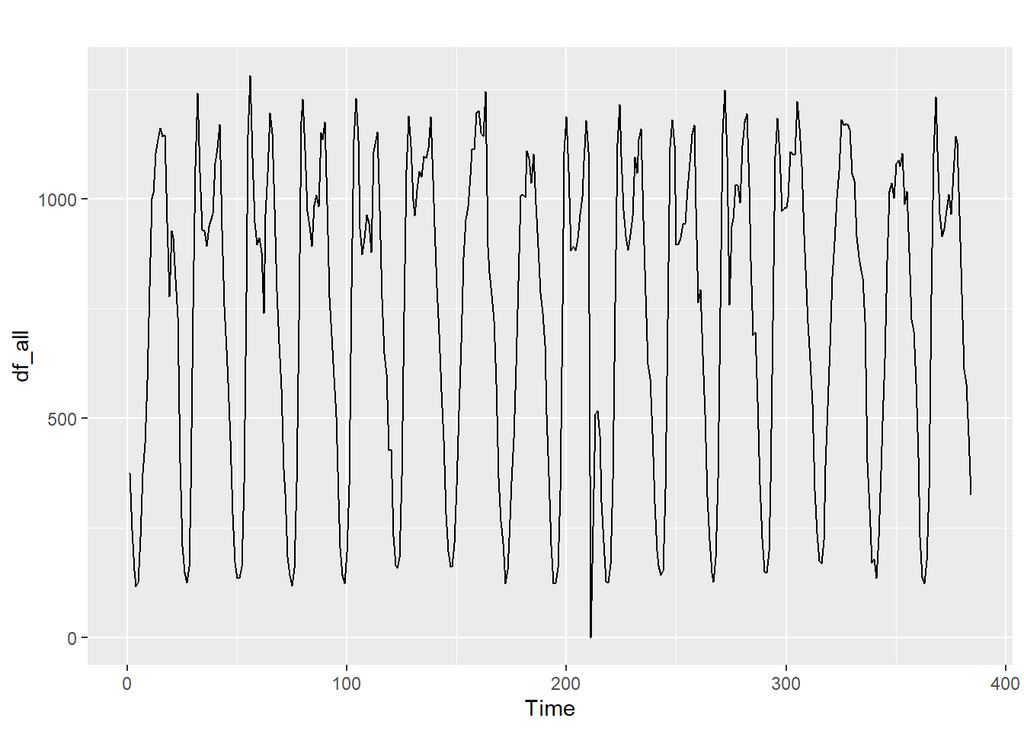

```r
file.list <- list.files(pattern='*.xls', recursive = TRUE)
dat <- lapply(file.list, function(i){
  x = read_excel(i, skip = 1)
  x = x %>% select(Time, I80E...5) %>% slice(3:26)
  x$file = i
  x
})
dat1 = do.call("rbind.data.frame", dat)
dat1$I80E...5 <- as.numeric(as.character(dat1$I80E...5))
matched <- dat1$file == 'Traffic Flow Data/Traffic Flow Data/I-57-2013-July-1.xls'
df <- rbind(dat1[!matched,], dat1[matched,])
df_all <- ts(df$I80E...5, frequency = 1)
autoplot(df_all)
```

### 2) Split Data & Plot

*Split the dataset into a training dataset which includes 6/16/2013 - 6/30/2013 samples and a test dataset which includes 7/1/2013 samples and plot the ACF and PACF.*

**Below are the training and test sets along with the ACF and PACF plots for each. I used the tdsisplay() function to plot the ACF and PACF for each dataset.**

#### Train set plots

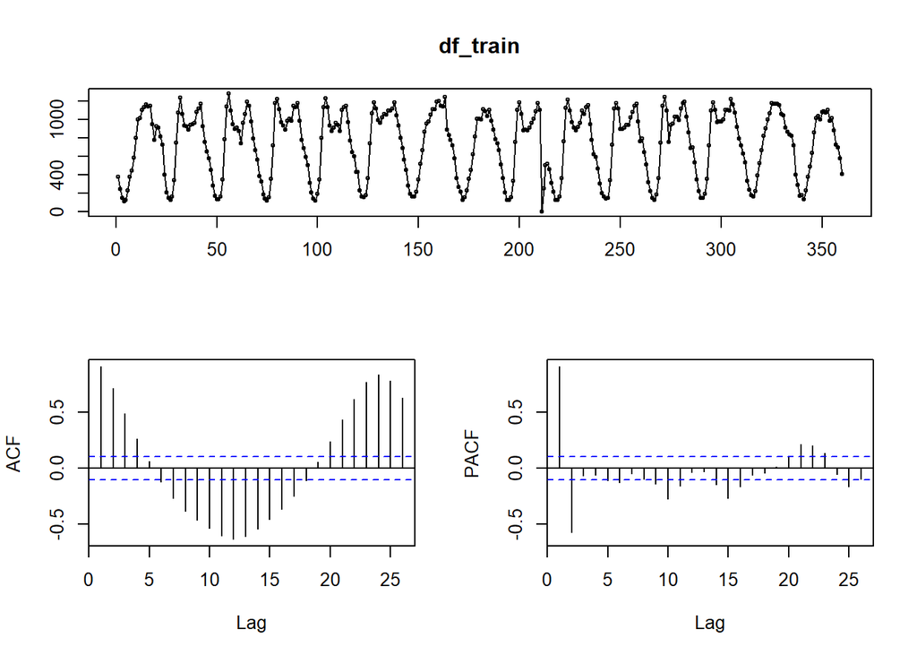

```r
train <- df %>% slice(1:360)
df_train <- ts(train$I80E...5, frequency = 1)
tsdisplay(df_train)
```

#### Test set plots

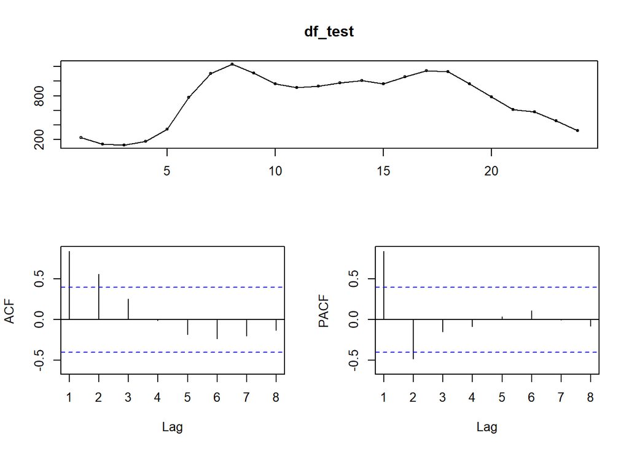

```r
test <- df %>% slice(361:384)
df_test <- ts(test$I80E...5, frequency = 1)
tsdisplay(df_test)
```

### 3) Build ARIMA(p,d,q)

*Build an ARIMA(p,d,q) model using the training dataset and R auto.arima() function. Change the values of p and q and determine the best model using AICc and BIC values. Do AICc and BIC select the same model as the best model? For each derived model, review the residual plots for the residuals ACF and normality.*

**The auto.arima() function selected ARIMA(2,0,3) as the best model. To test a few more models, I generated the EACF matrix. Based on the matrix, I investigated ARIMA(2,0,0) and ARIMA(2,0,1) models. I reviewed the BoxCox value and because lambda is so close to one, no transformation is necessary**

**The ARIMA(2,0,3) model has the lowest AICc and is therefore the best model out of the models tested. Also, in this instance, the BIC selects the same best model. ARIMA(2,0,3) has the lowest AICc and the lowest BIC.**

#### auto.arima() model

```r
auto.arima(df_train, seasonal = FALSE)
```

```
## Series: df_train
## ARIMA(2,0,3) with non-zero mean
##
## Coefficients:
##          ar1      ar2      ma1      ma2      ma3      mean
##       1.8088  -0.8853  -0.5348  -0.2671  -0.1157  746.3181
## s.e.  0.0288   0.0287   0.0600   0.0596   0.0654    6.8586
##
## sigma^2 estimated as 13443:  log likelihood=-2220.78
## AIC=4455.56   AICc=4455.88   BIC=4482.77
```

#### auto.arima() Residuals

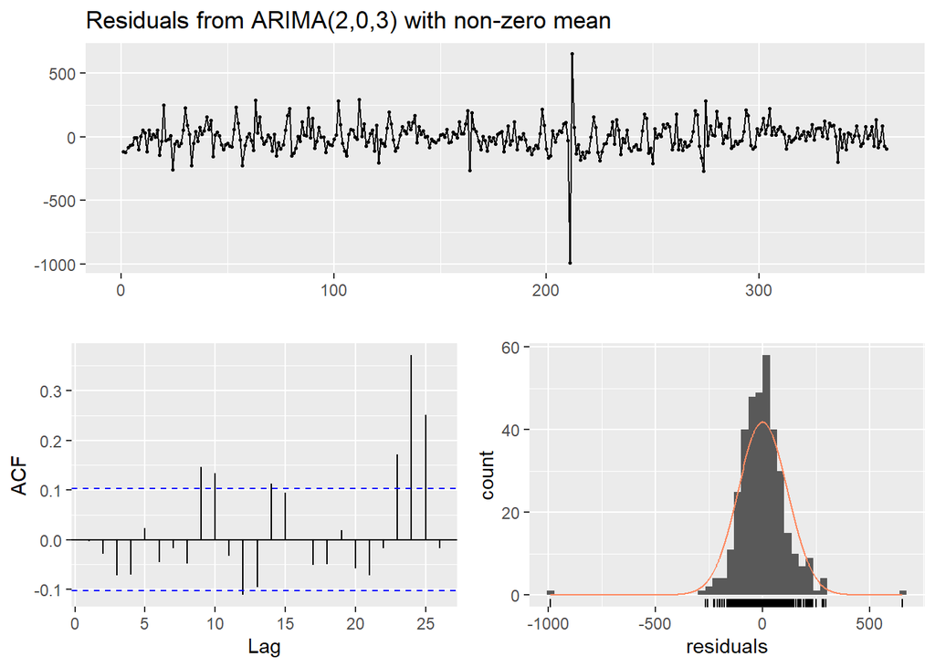

```
##
##  Ljung-Box test
##
## data:  Residuals from ARIMA(2,0,3) with non-zero mean
## Q* = 20.439, df = 4, p-value = 0.0004089
##
## Model df: 6.   Total lags used: 10
```

```r
auto_arima <- auto.arima(df_train, seasonal = FALSE)
checkresiduals(auto_arima)
```

#### ARIMA(2,0,0)

```r
arima200 <- Arima(df_train ,order = c(2,0,0));arima200
```

```
## Series: df_train
## ARIMA(2,0,0) with non-zero mean
##
## Coefficients:
##          ar1      ar2      mean
##       1.4390  -0.5890  739.0216
## s.e.  0.0425   0.0426   43.0839
##
## sigma^2 estimated as 15307:  log likelihood=-2245.08
## AIC=4498.16   AICc=4498.28   BIC=4513.71
```

#### ARIMA(2,0,0) Residuals

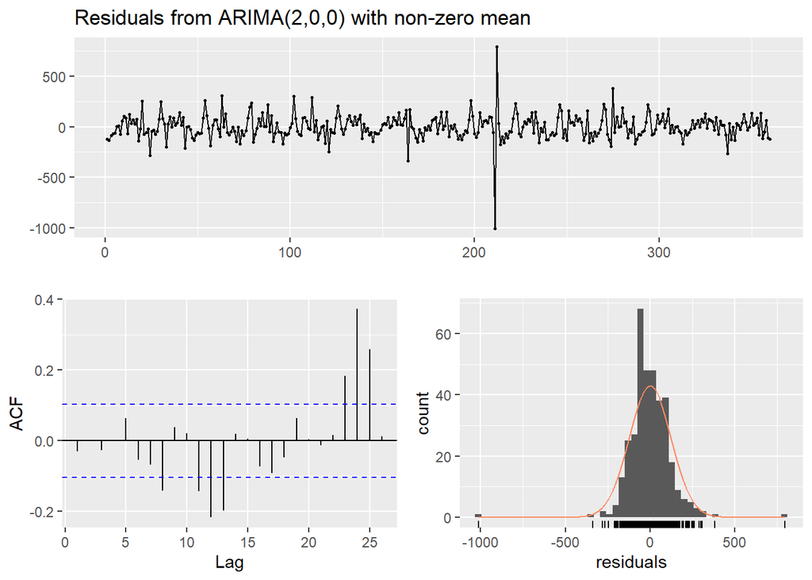

```
##
##  Ljung-Box test
##
## data:  Residuals from ARIMA(2,0,0) with non-zero mean
## Q* = 12.992, df = 7, p-value = 0.07231
##
## Model df: 3.   Total lags used: 10
```

```r
checkresiduals(arima200)
```

#### ARIMA(2,0,1)

```r
arima201 <- Arima(df_train ,order = c(2,0,1));arima201
```

```
## Series: df_train
## ARIMA(2,0,1) with non-zero mean
##
## Coefficients:
##          ar1      ar2      ma1      mean
##       1.5254  -0.6671  -0.1343  740.0717
## s.e.  0.0776   0.0714   0.1109   39.4450
##
## sigma^2 estimated as 15282:  log likelihood=-2244.29
## AIC=4498.59   AICc=4498.76   BIC=4518.02
```

#### ARIMA(2,0,1) Residuals

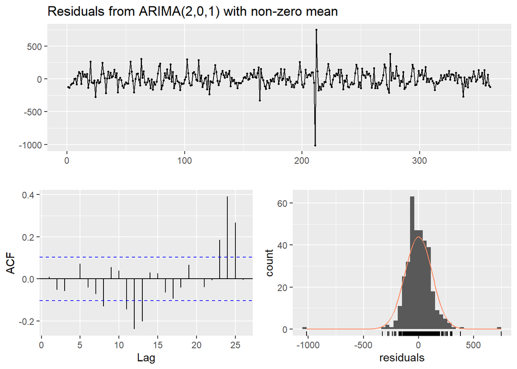

```
##
##  Ljung-Box test
##
## data:  Residuals from ARIMA(2,0,1) with non-zero mean
## Q* = 14.715, df = 6, p-value = 0.02259
##
## Model df: 4.   Total lags used: 10
```

```r
checkresiduals(arima201)
```

#### EACF Matrix

```r
eacf(df_train)
```

```
## AR/MA
##   0 1 2 3 4 5 6 7 8 9 10 11 12 13
## 0 x x x x o x x x x x x  x  x  x
## 1 x x x x o x x x o o x  x  x  x
## 2 o o x o o o o x x o o  x  x  x
## 3 x o o x o o o o o o o  o  x  o
## 4 x x o x o o o o o o o  o  o  o
## 5 x x x o o o o o o o o  o  o  o
## 6 x x x x o o o o o o o  o  o  o
## 7 x x o x x o o o o x o  o  o  o
```

#### BoxCox Recommendation

```r
BoxCox.lambda(df_train)
```

```
## [1] 1.084656
```

### 4) Day of the Week Model

*Build a day of the week seasonal ARIMA(p,d,q)(P,D,Q)s model using the training dataset and R auto.arima() function..*

**Below is the development of the Day of the Week time series data. After generating a new time series dataset, I executed the auto.arima() function and the model selected was ARIMA(0,1,2)(0,1,0)[168]**

#### Day of the Week Model

```r
weekly_df_train <- ts(train$I80E...5, frequency = 168)

auto.arima(weekly_df_train)
```

```
## Series: weekly_df_train
## ARIMA(0,1,2)(0,1,0)[168]
##
## Coefficients:
##           ma1      ma2
##       -0.4741  -0.4853
## s.e.   0.0593   0.0586
##
## sigma^2 estimated as 7081:  log likelihood=-1121.66
## AIC=2249.31   AICc=2249.44   BIC=2259.07
```

### 5) Day of Week Forecast

*Use the ARIMA(p,d,q)(P,D,Q)s model from Question 4 to forecast for July 1st (which is a Monday). Plot your result.*

**Below is the forecast from the fitted model from question 4. You can tell from the days of the week that Monday through Friday have the same pattern and that pattern changes on Saturday and Sunday. The forecast aligns with the pattern of the data. You can see that the forecast is for a Monday.**

#### Day of Week Forecast

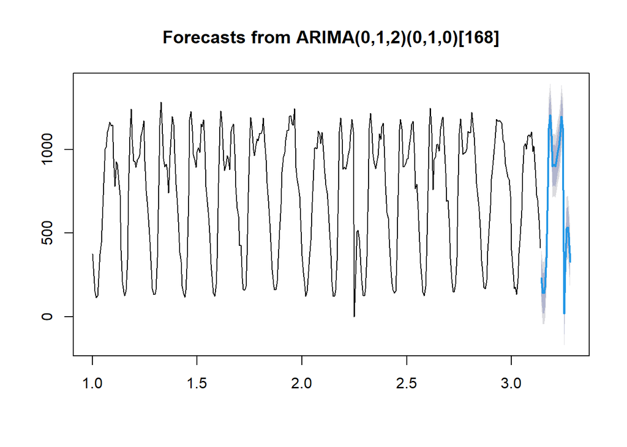

```r
fit_Q5 <- Arima(weekly_df_train,order=c(0,1,2),seasonal=list(order=c(0,1,0),period=168))
fc_Q5 <- forecast(weekly_df_train, h = 24 ,model = fit_Q5)
plot(fc_Q5)
```

### 6) Hour of Day Model

*Build a hour of the day seasonal ARIMA(p,d,q)(P,D,Q)s model using the training dataset and R auto.arima() function.*

**Below is the development of the Hour of the Day time series data. After generating a new time series dataset, I executed the auto.arima() function and the model selected was ARIMA(2,0,2)(2,1,0)[24]**

#### Hour of Day Model

```r
hourly_df_train <- ts(train$I80E...5, frequency = 24)
auto.arima(hourly_df_train)
```

```
## Series: hourly_df_train
## ARIMA(2,0,2)(2,1,0)[24]
##
## Coefficients:
##          ar1      ar2      ma1      ma2     sar1     sar2
##       1.5965  -0.6895  -0.6772  -0.1650  -0.4151  -0.3254
## s.e.  0.0639   0.0521   0.0815   0.0694   0.0565   0.0535
##
## sigma^2 estimated as 11243:  log likelihood=-2045.28
## AIC=4104.56   AICc=4104.9   BIC=4131.28
```

### 7) Hour of Day Forecast

*Use the ARIMA(p,d,q)(P,D,Q)s model from Question 6 to forecast for July 1st (which is a Monday). Plot your result.*

**Below is the forecast from the fitted model from question 6. You can tell from the days of the week that Monday through Friday have the same pattern and that pattern changes on Saturday and Sunday. However, the forecast appears to break with the weekly pattern. It appears that the forecast looks like an extension of the pattern from Saturday and Sunday.**

#### Hour of the Day Forecast

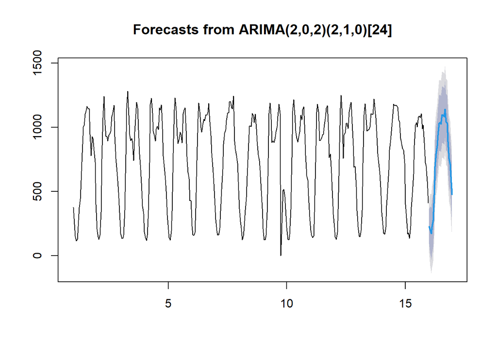

```r
fit_Q7 <- Arima(hourly_df_train,order=c(2,0,2),seasonal=list(order=c(2,1,0),period=24))
fc_Q7 <- forecast(hourly_df_train, h = 24 ,model = fit_Q7)
plot(fc_Q7)
```

### 8) Compare Forecasts

*Compare the forecast of the models from Questions 5 and 7 for July 1 8:00, 9:00, 17:00 and 18:00, which model is better (Questions 4 or 6)?*

**Based on the errors from both models from question 4 and question 6, it is clear that the model from question 4 has less error and better fits the model. This aligns with the weekly pattern seen in the plots. The forecast from the model from question 4 looks like it aligns with a Monday through Friday pattern. It should, because the forecast is for a Monday and can be seen in the smaller errors at the selected times used in the comparisons.**

#### Question 4 Model

```r
error8am <- df_test[8] - fc_Q5$mean[8];error8am
```

```
## [1] 27.02145
```

```r
error9am <- df_test[9] - fc_Q5$mean[9];error9am
```

```
## [1] 29.02145
```

```r
error5pm <- df_test[17] - fc_Q5$mean[17];error5pm
```

```
## [1] -54.97855
```

```r
error6pm <- df_test[18] - fc_Q5$mean[18];error6pm
```

```
## [1] 3.021445
```

#### Question 6 Model

```r
error8am <- df_test[8] - fc_Q7$mean[8];error8am
```

```
## [1] 438.836
```

```r
error9am <- df_test[9] - fc_Q7$mean[9];error9am
```

```
## [1] 255.4618
```

```r
error5pm <- df_test[17] - fc_Q7$mean[17];error5pm
```

```
## [1] 2.70009
```

```r
error6pm <- df_test[18] - fc_Q7$mean[18];error6pm
```

```
## [1] 87.03887
```